# Modeling Project

Austin Anderson

# Packages

```r
library(dplyr)
```

```r
library(tidyr)
library(ggplot2)
library(scales)
library(gridExtra)
library(broom)
library(tidyverse)
library(rvest)
library(lubridate)
library(xml2)
library(broom)
library(car)
library(broom)
library(mosaic)
library(igraph)
```

# Intro

Air travel is becoming a ubiquitous part of modern life. with recent news of Boeing 747 having to make emergency landing because of issues with flight technology, I wanted to know how Plane type and operators, affected the fatalities and survivors.

# Data Importing with Formatting dates

```r
Air <- read_csv("Airplane_Crashes_and_Fatalities_Since_1908.csv",
    col_types = cols(Date = col_date(format = "%m/%d/%Y")))
```

# Cleaning

```r
#Omiting NA
Air$Fatalities[is.na(Air$Fatalities)] = 0

#Calculate Survivors
Air$Survived = Air$Aboard - Air$Fatalities

summary(Air$Survived)
```

```
##    Min. 1st Qu.  Median    Mean 3rd Qu.    Max.    NA's
##   0.000   0.000   0.000   7.471   2.000 516.000      22
```

# Exploratroty Graphs

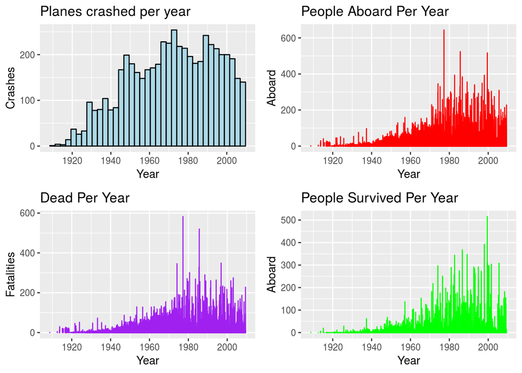

```r
dead_per_year = ggplot(Air, aes(Date, Fatalities)) +
    geom_bar(na.rm = TRUE, stat="identity", position="identity", colour="purple") + scale_x_date() + xlab("Year") + ylab("Fatalities") + ggtitle("Dead Per Year")

crash_per_year = ggplot(Air, aes(Date)) +
    geom_histogram(binwidth=1000, fill="lightblue", col="black") +
    scale_x_date() + xlab("Year") + ylab("Crashes") + ggtitle("Planes crashed per year")

aboard_per_year = ggplot(Air, aes(Date, Aboard)) +
    geom_bar(na.rm = TRUE, stat="identity", position="identity", colour="red") + scale_x_date() + xlab("Year") + ylab("Aboard") + ggtitle("People Aboard Per Year")

survived_per_year = ggplot(Air, aes(Date, Survived)) +
    geom_bar(na.rm = TRUE, stat="identity", position="identity", colour="green") + scale_x_date() + xlab("Year") + ylab("Aboard") + ggtitle("People Survived Per Year")

grid.arrange(crash_per_year, aboard_per_year, dead_per_year, survived_per_year, ncol=2)
```

For the next visuals I wanted to look at top 25 Fatalities by Plane Type,Crashes by Operator,Crashes by Plane Type. To do so I aggragate data here to plot and visualize later

```r
#Fatalities by Plane Type
plane_type = aggregate(Air$Fatalities, by=list(Type=Air$Type), FUN=sum)
names(plane_type) = c("Type", "Fatalities")
plane_type = plane_type[ order(-plane_type$Fatalities), ]

# Crashes by Operator
data.operator = Air['Operator']
data.operator = data.frame(table(data.operator))
data.operator = data.operator[-c(1),]
data.operator = data.operator[ order(-data.operator$Freq), ]


# Crashes by Plane Type
data.type = Air['Type']
data.type = data.frame(table(data.type))
data.type = data.type[-c(1),]
data.type = data.type[ order(-data.type$Freq), ]
```

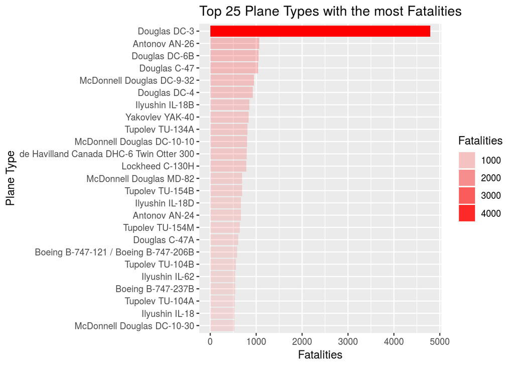

```r
ggplot(plane_type[1:25,], aes(x=reorder(factor(Type), Fatalities), y=Fatalities, alpha=Fatalities)) +
  geom_bar(stat = "identity", fill="red") +
  xlab("Plane Type") +
  ylab("Fatalities") +
  ggtitle("Top 25 Plane Types with the most Fatalities") +
  coord_flip()
```

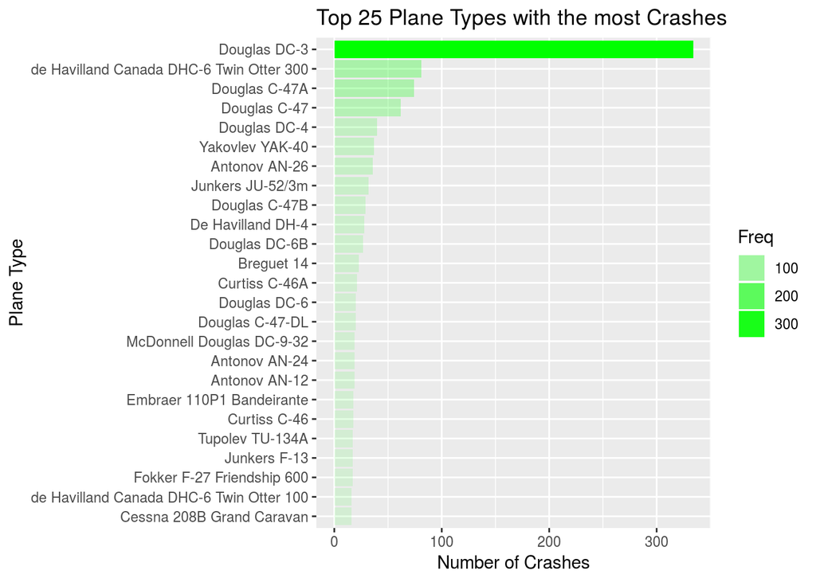

```r
ggplot(data.type[1:25,], aes(x=reorder(factor(data.type), Freq), y=Freq, alpha=Freq)) +
  geom_bar(stat = "identity", fill="green") +
  xlab("Plane Type") +
  ylab("Number of Crashes") +
  ggtitle("Top 25 Plane Types with the most Crashes") +
  coord_flip()
```

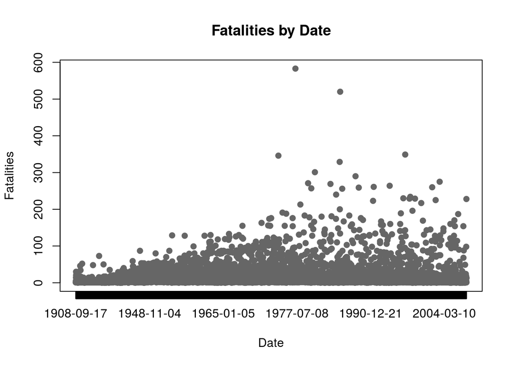

```r
stripchart(Air$Fatalities ~ Air$Date, main='Fatalities by Date', ylab='Fatalities', xlab='Date', method='jitter', pch=19, col=gray(0.4), vertical=TRUE)
```

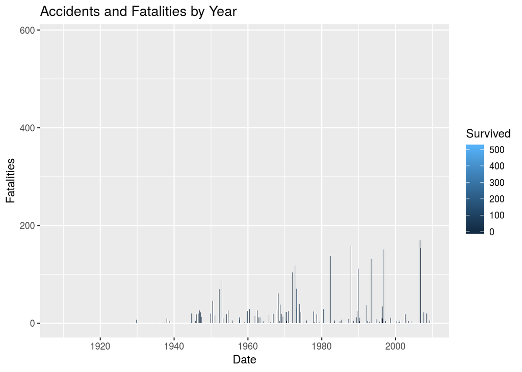

```r
# Plot "Accidents and Fatalities by Year"
ggplot(Air, aes(x = Date, y = Fatalities, fill = Survived)) + geom_bar(stat = "identity") + ggtitle("Accidents and Fatalities by Year")
```

# Multiple Linear regression

You will go through two “mechanical” tasks that demonstrate your ability to run basic types of analysis in R. These tasks will not necessarily be “good” models and you don’t need to worry about the conclusions expressing anything meaningful. Here are the two tasks you need to complete:

Use a numerical response variable, one numerical explanatory variable, and one categorical explanatory variable. Allow R to use the default dummy coding with the categorical variable. Using the total number of people on board by, the total number of fatalities, plus the type of plane that crashed.

```r
AirLM <- lm(Aboard ~ Fatalities + Type, data = Air)
```

```r
AirLMTidy<-tidy(AirLM)
AirLMTidy
```

```
## # A tibble: 2,440 x 5
##    term                             estimate std.error statistic   p.value
##    <chr>                               <dbl>     <dbl>     <dbl>     <dbl>
##  1 (Intercept)                        12.6     15.6        0.810 4.18e-  1
##  2 Fatalities                          0.624    0.0141    44.2   3.00e-323
##  3 TypeAEGK                          -10.8     22.1       -0.488 6.26e-  1
##  4 TypeAermacchi MB-339PAN (3 airc…  -11.5     22.1       -0.522 6.02e-  1
##  5 TypeAero Commander 500A           -10.0     22.1       -0.454 6.50e-  1
##  6 TypeAero Commander 500-B          -11.9     22.1       -0.539 5.90e-  1
##  7 TypeAero Commander  520           -10.4     22.1       -0.471 6.38e-  1
##  8 TypeAero Commander 560            -11.9     22.1       -0.539 5.90e-  1
##  9 TypeAero Commander 560-A          -10.8     22.1       -0.488 6.26e-  1
## 10 TypeAero Commander 560-F          -11.5     22.1       -0.522 6.02e-  1
## # ... with 2,430 more rows
```

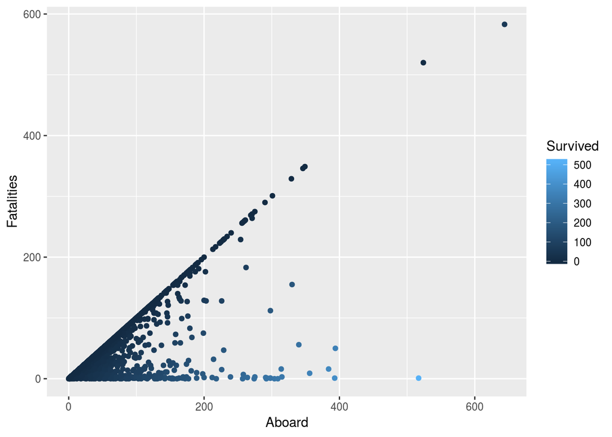

```r
ggplot(data = Air,aes(y = Fatalities, x = Aboard)) + geom_point(aes(color = Survived))
```

we can see the presense of outliers but there is a clear relationship between fatalities and people aboard in my plane crash data set

Simple Linear Model

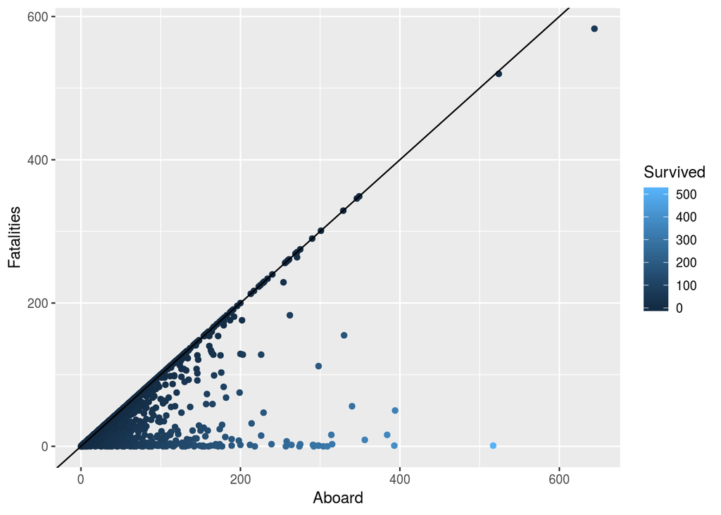

```r
ggplot(data = Air,aes(y = Fatalities, x = Aboard)) + geom_point(aes(color = Survived))+geom_abline()
```

This model seems to be okay fit but not a stricly linear relationship.

# Methods and Materials

Mechanical tasks Interpret the ANOVA table for the model. Test for the presence of interaction between the two explanatory variables both graphically and statistically.

# ANOVA

Using a numerical response variable, and two categorical explanatory variables. Use deviance coding with “contr.sum”. (was not useful for my data set due to my dataframe not having factor variables)

```r
Air2 <- Air
Air2$Type<- factor(Air2$Type)
contrasts(Air2$Type) = "contr.sum"
Air2$Operator<- factor(Air2$Operator)
contrasts(Air2$Operator) = "contr.sum"
Air2$Survived <- factor(Air2$Survived)
contrasts(Air2$Survived) = "contr.sum"
```

```r
Airlm2<-lm(Aboard ~ Fatalities + Type:Survived, data = Air)
head_print(Airlm2, n = 20)
```

```
##
## Call:
## lm(formula = Aboard ~ Fatalities + Type:Survived, data = Air)
##
## Coefficients:
##                                           (Intercept)
##                                             8.496e-13
##                                            Fatalities
##                                             1.000e+00
##                             TypeAAC-1 Toucan:Survived
##                                             1.000e+00
##                                     TypeAEGK:Survived
##                                                    NA
##         TypeAermacchi MB-339PAN (3 aircraft):Survived
##                                                    NA
##                      TypeAero Commander 500A:Survived
##                                                    NA
##                     TypeAero Commander 500-B:Survived
##                                                    NA
##                      TypeAero Commander  520:Survived
```

Interpret the coefficients of the model including the intercept and the interaction terms (even when such coefficients might not make any sense for a variety of reasons).

These coefficients do make sense, they just have a lot of different types for each plane type, coresponding to any surviors that were reported, if the value for the NA Fattaliteis = Aboard, or Fattalities = 0, if there were surviours, such as in later plane types, therer will be a coeffiecent relating If that plane type is likely to have surviours

```r
Airlm3<-lm(Aboard ~ Fatalities + Type, data = Air2)
head_print(Airlm3, n = 20)
```

```
##
## Call:
## lm(formula = Aboard ~ Fatalities + Type, data = Air2)
##
## Coefficients:
##                                  (Intercept)
##                                    12.636939
##                                   Fatalities
##                                     0.624481
##                                     TypeAEGK
##                                   -10.759344
##         TypeAermacchi MB-339PAN (3 aircraft)
##                                   -11.510382
##                      TypeAero Commander 500A
##                                   -10.008306
##                     TypeAero Commander 500-B
##                                   -11.885901
##                      TypeAero Commander  520
##                                   -10.383825
##                       TypeAero Commander 560
```

```r
Anova(lm(Aboard ~ Fatalities + Type, data = Air2))
```

```
## Anova Table (Type II tests)
##
## Response: Aboard
##             Sum Sq   Df   F value    Pr(>F)
## Fatalities  474716    1 1949.9116 < 2.2e-16 ***
## Type       3474443 2438    5.8537 < 2.2e-16 ***
## Residuals   677049 2781
## ---
## Signif. codes:  0 '***' 0.001 '**' 0.01 '*' 0.05 '.' 0.1 ' ' 1
```

```r
AirLm6 <- lm(Aboard ~ Fatalities + Operator, data = Air2)
head_print(AirLm6, n = 20)
```

```
##
## Call:
## lm(formula = Aboard ~ Fatalities + Operator, data = Air2)
##
## Coefficients:
##                                                               (Intercept)
##                                                                 4.841e-01
##                                                                Fatalities
##                                                                 8.386e-01
##                                                 OperatorAbabeel Aviaition
##                                                                 1.614e-01
##                                                 OperatorA B Aerotransport
##                                                                 6.758e+00
##                                                  OperatorAB Aerotransport
##                                                                 4.635e+00
##                                                   OperatorAbakan Airlines
##                                                                 1.600e+01
##                                                       OperatorAca-Ancargo
##                                                                 6.615e+00
##                                                OperatorAce Flying Service
```

The Interaction model, has some issues I wont put it in a code chunk or this document will not knit however due to the variablity in surviability by plane type I ran into an issue with file size.  
`Anova(lm(Aboard ~ Fatalities + Type:Survived, data = Air2))`

Could not complete anova table with counter sum, due to the size of my data set. I got an error saying “cannot allocate vector of size 15.9 Gb” I think that it is due to the survived factor being so large

Running Anova without survived factor variable, we find that survived was the issue, creating a very high file size. So lets try with a smaller data framer such as type

```r
Anova(lm(Aboard ~ Fatalities + Type, data = Air2))
```

```
## Anova Table (Type II tests)
##
## Response: Aboard
##             Sum Sq   Df   F value    Pr(>F)
## Fatalities  474716    1 1949.9116 < 2.2e-16 ***
## Type       3474443 2438    5.8537 < 2.2e-16 ***
## Residuals   677049 2781
## ---
## Signif. codes:  0 '***' 0.001 '**' 0.01 '*' 0.05 '.' 0.1 ' ' 1
```

That works

Now trying to use location we find that it doesnt work due to its size. `Anova(lm(Aboard ~ Fatalities + Location, data = Air2))`

Same issue here, to big of file this time the error read " cannot allocate vector of size 140.3 Mb"

# Interpreting the ANOVA table for the model.

Using the total number of people on board by, the total number of fatalities, plus the type of plane that crashed. We can see that fatalities has a higher f value than our F statistic, and is shown to be significant in predicting the ammount of people who were on board, in the airplane crash data set. Type is also significant, but not as much as Fatalities.

Test for the presence of interaction between the two explanatory variables both graphically and statistically.

# Calculating Group means

```r
Location_means <- Air %>%
group_by(Fatalities,Location) %>%
summarize(mean_Fatalities = mean(Fatalities))
Location_means
```

```
## # A tibble: 5,137 x 3
## # Groups:   Fatalities [?]
##    Fatalities Location                               mean_Fatalities
##         <dbl> <chr>                                            <dbl>
##  1          0 300 nm NW of San Francisco, California               0
##  2          0 Amsterdam, Netherlands                               0
##  3          0 Anchorage, Alaska                                    0
##  4          0 Atlanta, Georgia                                     0
##  5          0 Bacolod, Philippines                                 0
##  6          0 Bangui, Central African Republic                     0
##  7          0 Bartlesville, Oklahoma                               0
##  8          0 Between Chungking and Shanghai, China                0
##  9          0 Boston, Massachusetts                                0
## 10          0 Burbank, Calilfornia                                 0
## # ... with 5,127 more rows
```

```r
Type_means <- Air %>%
group_by(Fatalities,Type) %>%
summarize(mean_Fatalities = mean(Fatalities))
Type_means
```

```
## # A tibble: 4,235 x 3
## # Groups:   Fatalities [?]
##    Fatalities Type                       mean_Fatalities
##         <dbl> <chr>                                <dbl>
##  1          0 Airbus A300B4-622R                       0
##  2          0 Airbus A.320-214                         0
##  3          0 Airbus A320-214                          0
##  4          0 Airbus A-330-243                         0
##  5          0 Airbus A-340                             0
##  6          0 Antonov 12                               0
##  7          0 BAC One-Eleven 528FL                     0
##  8          0 Bell UH-1B Huey Helicopter               0
##  9          0 Boeing  377 Stratocruiser                0
## 10          0 Boeing 777-236ER                         0
## # ... with 4,225 more rows
```

```r
Operator_means <- Air %>%
group_by(Fatalities,Operator) %>%
summarize(mean_Fatalities = mean(Fatalities))
Operator_means
```

```
## # A tibble: 4,370 x 3
## # Groups:   Fatalities [?]
##    Fatalities Operator                       mean_Fatalities
##         <dbl> <chr>                                    <dbl>
##  1          0 Aeroflot                                     0
##  2          0 Aeromexico                                   0
##  3          0 Air Canada                                   0
##  4          0 Aircraft Transport and Travel                0
##  5          0 Air France                                   0
##  6          0 American Airlines                            0
##  7          0 American International Airways               0
##  8          0 Ararat Avia                                  0
##  9          0 British Airways                              0
## 10          0 Canadian Air Transat                         0
## # ... with 4,360 more rows
```

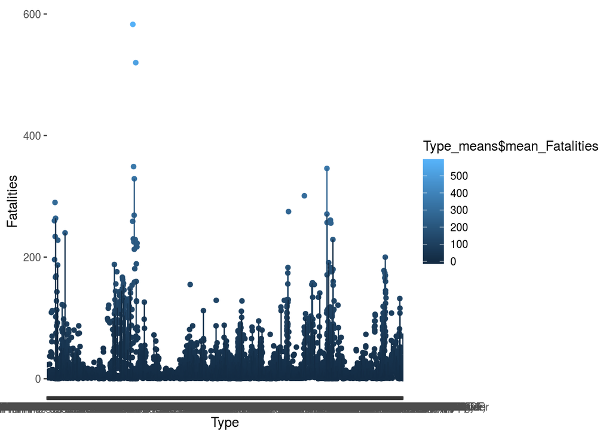

```r
ggplot(Air, aes(y = Fatalities , x = Type, color = Type_means$mean_Fatalities)) + geom_point(data = Type_means, aes(y = mean_Fatalities , x = Type)) + geom_line(data = Type_means, aes(y = mean_Fatalities, x = Type))
```

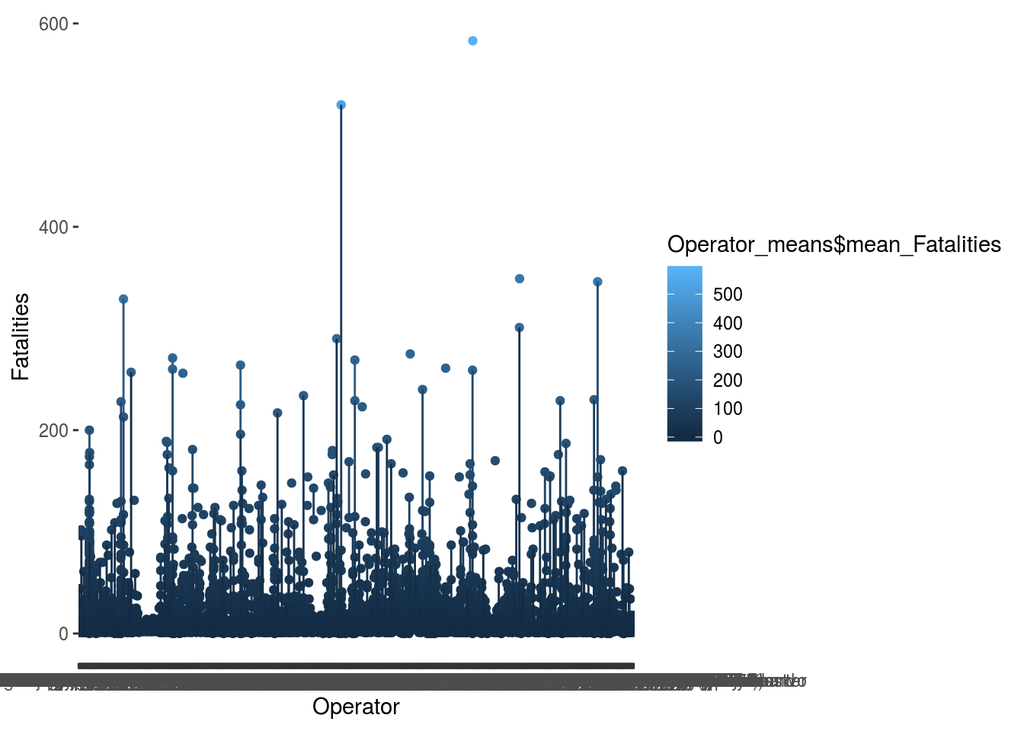

```r
ggplot(Air, aes(y = Fatalities , x = Operator, color = Operator_means$mean_Fatalities)) + geom_point(data = Operator_means, aes(y = mean_Fatalities , x = Operator)) + geom_line(data = Operator_means, aes(y = mean_Fatalities, x = Operator))
```

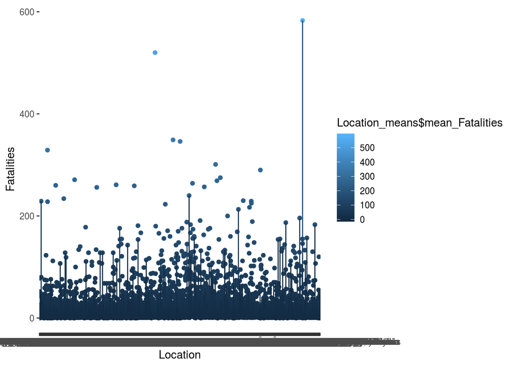

```r
ggplot(Air, aes(y = Fatalities , x = Location, color = Location_means$mean_Fatalities)) + geom_point(data = Location_means, aes(y = mean_Fatalities , x = Location)) + geom_line(data = Location_means, aes(y = mean_Fatalities, x = Location))
```

# Meaningful model

Specify a contextually meaningful model that tests a reasonable hypothesis. (It could be one of the models you tested above, or it could be a completely different model.) In addition to the steps you have done above, be sure to transform any variables that need transforming, do a thorough search for outliers and test them for influence, and run any other model diagnostics that are appropriate for your specific data. Use your model to come to a meaningful conclusion and learn something from your analysis.

```r
summary(Air2$Type)
```

```
##                             Douglas DC-3
##                                      334
## de Havilland Canada DHC-6 Twin Otter 300
##                                       81
##                            Douglas C-47A
##                                       74
##                             Douglas C-47
##                                       62
##                             Douglas DC-4
##                                       40
##                          Yakovlev YAK-40
##                                       37
##                            Antonov AN-26
##                                       36
##                         Junkers JU-52/3m
##                                       32
##                            Douglas C-47B
##                                       29
##                        De Havilland DH-4
##                                       28
##                            Douglas DC-6B
##                                       27
##                               Breguet 14
##                                       23
##                            Curtiss C-46A
##                                       21
##                          Douglas C-47-DL
##                                       20
##                             Douglas DC-6
##                                       20
##                            Antonov AN-12
##                                       19
##                            Antonov AN-24
##                                       19
##                McDonnell Douglas DC-9-32
##                                       19
##                             Curtiss C-46
##                                       18
##                Embraer 110P1 Bandeirante
##                                       18
```

[output cut: 145 more lines]

```
##                                        7
##                        Boeing B-707-321B
##                                        7
##                               Cessna 207
##                                        7
##                         Douglas DC-2-112
##                                        7
##                         Fairchild C-123K
##                                        7
##                           Ilyushin IL-14
##                                        7
##                                  (Other)
##                                     3431
##                                     NA's
##                                       27
```

I believe the most suitable model is type of plane in a additve model, used to predict the ammount of people on board given the type of plane and number of Fattalities. (I do not believe that this is a relatistic model, but it is more contextly meaningful than other models tested above) Due to the variablility of plane type. With each itteration of plane having different life cycles, and capacities that I wish I had for my analysis. This is my most responable model.

```r
Anova(lm(Aboard ~ Fatalities + Type, data = Air2))
```

```
## Anova Table (Type II tests)
##
## Response: Aboard
##             Sum Sq   Df   F value    Pr(>F)
## Fatalities  474716    1 1949.9116 < 2.2e-16 ***
## Type       3474443 2438    5.8537 < 2.2e-16 ***
## Residuals   677049 2781
## ---
## Signif. codes:  0 '***' 0.001 '**' 0.01 '*' 0.05 '.' 0.1 ' ' 1
```

# Discussion

This is historical plane crash data, as such each row of data was an individual plane crash. It is not probable that one could use this dataset to predict future plane crashes.

# Literature cited

https://www.kaggle.com/saurograndi/airplane-crashes-since-1908/discussion https://stackoverflow.com/questions